# **Joann Chan**

### *Most Popular Baby Names*

**This dataset can be downloaded *[HERE](http://localhost:8888/view/seaborn-data/babynames.csv)***

The dataset displayed is of the most popular baby names in New York City. The data is based off of the baby's sex and the mother's ethnicity. There are multiple variables that are included. Here is a breakdown of them:

**Year of Birth**:

- What year the baby is born. This dataset has information from years ranging from 2011-2014.

**Gender**:

- Whether the baby is male or female can contribute largly to what name is being given.

**Ethnicty**:

- This is **NOT** the ethnicity of the baby, but of the mother.

**Child's First Name**:

- This is the name given to the child that is born.

**Count**:

- This indicates how many children are named whatever is under *Child's First Name*, given that the following are the same: *Year of birth*, *Gender*, and *Ethnicity*(of mother).

**Rank**:

- This indicates the popularity of the name given to the baby

```python
%matplotlib inline
import matplotlib.pyplot as plt
import numpy as np
import pandas as pd
import seaborn as sns
```

```python
names = sns.load_dataset("babynames")
```

```python
names.to_csv('projectA/babynames.csv')
```

```python
type(names)
```

```
pandas.core.frame.DataFrame
```

# Most Popular Baby Names in NYC Table

```python
names.head()
```

|  | Year of Birth | Gender | Ethnicity | Child's First Name | Count | Rank |
| --- | --- | --- | --- | --- | --- | --- |
| 0 | 2011 | FEMALE | HISPANIC | GERALDINE | 13 | 75 |
| 1 | 2011 | FEMALE | HISPANIC | GIA | 21 | 67 |
| 2 | 2011 | FEMALE | HISPANIC | GIANNA | 49 | 42 |
| 3 | 2011 | FEMALE | HISPANIC | GISELLE | 38 | 51 |
| 4 | 2011 | FEMALE | HISPANIC | GRACE | 36 | 53 |

*We can see that this data table only shows the first five rows for each column. To get a wider range of each variable, we will slice the data by columns.*

# Year of Birth

```python
year = names["Year of Birth"]
```

```python
year.head()
```

```
0    2011
1    2011
2    2011
3    2011
4    2011
Name: Year of Birth, dtype: int64
```

By putting the command *.head( )* next to *year*, we are able to see only the first 5 entries of that column

*If we want to see the column's entries from beginning to end, we would remove the command.*

```python
year
```

```
0        2011
1        2011
2        2011
3        2011
4        2011
5        2011
6        2011
7        2011
8        2011
9        2011
10       2011
11       2011
12       2011
13       2011
14       2011
```

[output cut: 47 more lines]

*Here we see much more data than given from the table. We are able to see that the years actually range from 2011-2014. We can also see that from the years 2011-2014 there were 22,035 names being recorded*

# Gender

```python
gender = names["Gender"]
```

```python
gender.head()
```

```
0    FEMALE
1    FEMALE
2    FEMALE
3    FEMALE
4    FEMALE
Name: Gender, dtype: object
```

By putting the command *.head( )* next to *gender*, we are able to see only the first 5 entries of that column

*If we want to see the column's entries from beginning to end, we would remove the command.*

```python
gender
```

```
0        FEMALE
1        FEMALE
2        FEMALE
3        FEMALE
4        FEMALE
5        FEMALE
6        FEMALE
7        FEMALE
8        FEMALE
9        FEMALE
10       FEMALE
11       FEMALE
12       FEMALE
13       FEMALE
14       FEMALE
```

[output cut: 47 more lines]

*From the datatable, we would have assumed that the entries were only being given for females. However, when we sliced the data, we were able to see that males and females were both envolved in the dataset*

# Ethnicity

****Keep in mind that this is the ethnicity of the mother, **NOT** the child****

```python
ethnicity = names["Ethnicity"]
```

```python
ethnicity.head()
```

```
0    HISPANIC
1    HISPANIC
2    HISPANIC
3    HISPANIC
4    HISPANIC
Name: Ethnicity, dtype: object
```

By putting the command *.head( )* next to *ethnicity*, we are able to see only the first 5 entries of that column

*If we want to see the column's entries from beginning to end, we would remove the command.*

```python
ethnicity
```

```
0                  HISPANIC
1                  HISPANIC
2                  HISPANIC
3                  HISPANIC
4                  HISPANIC
5                  HISPANIC
6                  HISPANIC
7                  HISPANIC
8                  HISPANIC
9                  HISPANIC
10                 HISPANIC
11                 HISPANIC
12                 HISPANIC
13                 HISPANIC
14                 HISPANIC
```

[output cut: 47 more lines]

*We are able to see what ethnicity the mother of the child is*

# Child's First Name

```python
first = names["Child's First Name"]
```

```python
first.head()
```

```
0    GERALDINE
1          GIA
2       GIANNA
3      GISELLE
4        GRACE
Name: Child's First Name, dtype: object
```

By putting the command *.head( )* next to *first*, we are able to see only the first 5 entries of that column

*If we want to see the column's entries from beginning to end, we would remove the command.*

```python
first
```

```
0         GERALDINE
1               GIA
2            GIANNA
3           GISELLE
4             GRACE
5         GUADALUPE
6            HAILEY
7             HALEY
8            HANNAH
9            HAYLEE
10           HAYLEY
11            HAZEL
12           HEAVEN
13            HEIDI
14            HEIDY
```

[output cut: 47 more lines]

*Here we are able to see most of the names in alphabetical order*

*****Notice how there are no names from A-F. This could either mean that the dataset has some errors or that nobody, from the years 2011-2014, in NYC named their child with a name starting with any of the letters from A-F. The latter seems highly unlikely though.*****

*****Later on when we start grouping by columns, we can see that there are actually names that start with the letters A-F. The most likely reason why we cannot see it here is because the data is arranged in order of the year first, then the gender of the child, then the ethnicity of the mother, and then in alphabetical order. Looking at the first couple sets of data, we notice that we cannot see the males born, which contributes to our lack of seeing names starting with any of letters A-F.*****

# Count

```python
count = names["Count"]
```

```python
count.head()
```

```
0    13
1    21
2    49
3    38
4    36
Name: Count, dtype: int64
```

By putting the command *.head( )* next to *count*, we are able to see only the first 5 entries of that column

*If we want to see the column's entries from beginning to end, we would remove the command.*

```python
count
```

```
0         13
1         21
2         49
3         38
4         36
5         26
6        126
7         14
8         17
9         17
10        13
11        10
12        15
13        15
14        16
```

[output cut: 47 more lines]

*Here we are able to see the popularity for each of the names based off of the number of times that name was given to a child*

# Rank

```python
rank = names["Rank"]
```

```python
rank.head()
```

```
0    75
1    67
2    42
3    51
4    53
Name: Rank, dtype: int64
```

By putting the command *.head( )* next to *rank*, we are able to see only the first 5 entries of that column

*If we want to see the column's entries from beginning to end, we would remove the command.*

```python
rank
```

```
0         75
1         67
2         42
3         51
4         53
5         62
6          8
7         74
8         71
9         71
10        75
11        78
12        73
13        73
14        72
```

[output cut: 47 more lines]

# Using .iloc

```python
names.iloc[5:26]
```

|  | Year of Birth | Gender | Ethnicity | Child's First Name | Count | Rank |
| --- | --- | --- | --- | --- | --- | --- |
| 5 | 2011 | FEMALE | HISPANIC | GUADALUPE | 26 | 62 |
| 6 | 2011 | FEMALE | HISPANIC | HAILEY | 126 | 8 |
| 7 | 2011 | FEMALE | HISPANIC | HALEY | 14 | 74 |
| 8 | 2011 | FEMALE | HISPANIC | HANNAH | 17 | 71 |
| 9 | 2011 | FEMALE | HISPANIC | HAYLEE | 17 | 71 |
| 10 | 2011 | FEMALE | HISPANIC | HAYLEY | 13 | 75 |
| 11 | 2011 | FEMALE | HISPANIC | HAZEL | 10 | 78 |
| 12 | 2011 | FEMALE | HISPANIC | HEAVEN | 15 | 73 |
| 13 | 2011 | FEMALE | HISPANIC | HEIDI | 15 | 73 |
| 14 | 2011 | FEMALE | HISPANIC | HEIDY | 16 | 72 |
| 15 | 2011 | FEMALE | HISPANIC | HELEN | 13 | 75 |
| 16 | 2011 | FEMALE | HISPANIC | IMANI | 11 | 77 |
| 17 | 2011 | FEMALE | HISPANIC | INGRID | 11 | 77 |
| 18 | 2011 | FEMALE | HISPANIC | IRENE | 11 | 77 |
| 19 | 2011 | FEMALE | HISPANIC | IRIS | 10 | 78 |
| 20 | 2011 | FEMALE | HISPANIC | ISABEL | 28 | 60 |
| 21 | 2011 | FEMALE | HISPANIC | ISABELA | 10 | 78 |
| 22 | 2011 | FEMALE | HISPANIC | ISABELLA | 331 | 1 |
| 23 | 2011 | FEMALE | HISPANIC | ISABELLE | 18 | 70 |
| 24 | 2011 | FEMALE | HISPANIC | ISIS | 13 | 75 |
| 25 | 2011 | FEMALE | HISPANIC | ITZEL | 27 | 61 |

*Here we are able to see all the data from row #5-25*

**Notice that we cannot see row #26, even though we typed in from 5-26 in the command. The reason is because using *.iloc* will give us the data from one less than the row # we want to end at. If we typed in *.iloc[10:20]* we would get data from the rows numbered 10-19.**

# Using .loc

```python
names.loc[5:26]
```

|  | Year of Birth | Gender | Ethnicity | Child's First Name | Count | Rank |
| --- | --- | --- | --- | --- | --- | --- |
| 5 | 2011 | FEMALE | HISPANIC | GUADALUPE | 26 | 62 |
| 6 | 2011 | FEMALE | HISPANIC | HAILEY | 126 | 8 |
| 7 | 2011 | FEMALE | HISPANIC | HALEY | 14 | 74 |
| 8 | 2011 | FEMALE | HISPANIC | HANNAH | 17 | 71 |
| 9 | 2011 | FEMALE | HISPANIC | HAYLEE | 17 | 71 |
| 10 | 2011 | FEMALE | HISPANIC | HAYLEY | 13 | 75 |
| 11 | 2011 | FEMALE | HISPANIC | HAZEL | 10 | 78 |
| 12 | 2011 | FEMALE | HISPANIC | HEAVEN | 15 | 73 |
| 13 | 2011 | FEMALE | HISPANIC | HEIDI | 15 | 73 |
| 14 | 2011 | FEMALE | HISPANIC | HEIDY | 16 | 72 |
| 15 | 2011 | FEMALE | HISPANIC | HELEN | 13 | 75 |
| 16 | 2011 | FEMALE | HISPANIC | IMANI | 11 | 77 |
| 17 | 2011 | FEMALE | HISPANIC | INGRID | 11 | 77 |
| 18 | 2011 | FEMALE | HISPANIC | IRENE | 11 | 77 |
| 19 | 2011 | FEMALE | HISPANIC | IRIS | 10 | 78 |
| 20 | 2011 | FEMALE | HISPANIC | ISABEL | 28 | 60 |
| 21 | 2011 | FEMALE | HISPANIC | ISABELA | 10 | 78 |
| 22 | 2011 | FEMALE | HISPANIC | ISABELLA | 331 | 1 |
| 23 | 2011 | FEMALE | HISPANIC | ISABELLE | 18 | 70 |
| 24 | 2011 | FEMALE | HISPANIC | ISIS | 13 | 75 |
| 25 | 2011 | FEMALE | HISPANIC | ITZEL | 27 | 61 |
| 26 | 2011 | FEMALE | HISPANIC | IZABELLA | 23 | 65 |

*Here we are able to see data from the rows numbered 5-26*

**Notice how this table has data from the row numbered 26. The same numbers were punched into the command, so why would this one show the row numbered 26 while the previous one didn't? The answer is simple, we may have typed in the same numbers into the command, but the difference is that the commands have changed. The previous one used *.iloc*, which only gave us data from 5-25. By using *.loc*, we are able to get data from 5-26.**

# Using .loc on Variables

```python
names.loc[gender=="FEMALE"]
```

|  | Year of Birth | Gender | Ethnicity | Child's First Name | Count | Rank |
| --- | --- | --- | --- | --- | --- | --- |
| 0 | 2011 | FEMALE | HISPANIC | GERALDINE | 13 | 75 |
| 1 | 2011 | FEMALE | HISPANIC | GIA | 21 | 67 |
| 2 | 2011 | FEMALE | HISPANIC | GIANNA | 49 | 42 |
| 3 | 2011 | FEMALE | HISPANIC | GISELLE | 38 | 51 |
| 4 | 2011 | FEMALE | HISPANIC | GRACE | 36 | 53 |
| 5 | 2011 | FEMALE | HISPANIC | GUADALUPE | 26 | 62 |
| 6 | 2011 | FEMALE | HISPANIC | HAILEY | 126 | 8 |
| 7 | 2011 | FEMALE | HISPANIC | HALEY | 14 | 74 |
| 8 | 2011 | FEMALE | HISPANIC | HANNAH | 17 | 71 |
| 9 | 2011 | FEMALE | HISPANIC | HAYLEE | 17 | 71 |
| 10 | 2011 | FEMALE | HISPANIC | HAYLEY | 13 | 75 |
| 11 | 2011 | FEMALE | HISPANIC | HAZEL | 10 | 78 |
| 12 | 2011 | FEMALE | HISPANIC | HEAVEN | 15 | 73 |
| 13 | 2011 | FEMALE | HISPANIC | HEIDI | 15 | 73 |
| 14 | 2011 | FEMALE | HISPANIC | HEIDY | 16 | 72 |
| 15 | 2011 | FEMALE | HISPANIC | HELEN | 13 | 75 |
| 16 | 2011 | FEMALE | HISPANIC | IMANI | 11 | 77 |
| 17 | 2011 | FEMALE | HISPANIC | INGRID | 11 | 77 |
| 18 | 2011 | FEMALE | HISPANIC | IRENE | 11 | 77 |
| 19 | 2011 | FEMALE | HISPANIC | IRIS | 10 | 78 |
| 20 | 2011 | FEMALE | HISPANIC | ISABEL | 28 | 60 |
| 21 | 2011 | FEMALE | HISPANIC | ISABELA | 10 | 78 |
| 22 | 2011 | FEMALE | HISPANIC | ISABELLA | 331 | 1 |
| 23 | 2011 | FEMALE | HISPANIC | ISABELLE | 18 | 70 |
| 24 | 2011 | FEMALE | HISPANIC | ISIS | 13 | 75 |
| 25 | 2011 | FEMALE | HISPANIC | ITZEL | 27 | 61 |
| 26 | 2011 | FEMALE | HISPANIC | IZABELLA | 23 | 65 |
| 27 | 2011 | FEMALE | HISPANIC | JACQUELINE | 30 | 58 |
| 28 | 2011 | FEMALE | HISPANIC | JADA | 21 | 67 |
| 29 | 2011 | FEMALE | HISPANIC | JADE | 50 | 41 |
| ... | ... | ... | ... | ... | ... | ... |
| 21519 | 2014 | FEMALE | WHITE NON HISPANIC | Sylvie | 10 | 86 |
| 21520 | 2014 | FEMALE | WHITE NON HISPANIC | Talia | 49 | 47 |
| 21521 | 2014 | FEMALE | WHITE NON HISPANIC | Tamar | 12 | 84 |
| 21522 | 2014 | FEMALE | WHITE NON HISPANIC | Taylor | 24 | 72 |
| 21523 | 2014 | FEMALE | WHITE NON HISPANIC | Tess | 11 | 85 |
| 21524 | 2014 | FEMALE | WHITE NON HISPANIC | Tessa | 13 | 83 |
| 21525 | 2014 | FEMALE | WHITE NON HISPANIC | Thea | 11 | 85 |
| 21526 | 2014 | FEMALE | WHITE NON HISPANIC | Toby | 46 | 50 |
| 21527 | 2014 | FEMALE | WHITE NON HISPANIC | Trany | 12 | 84 |
| 21528 | 2014 | FEMALE | WHITE NON HISPANIC | Tzipora | 14 | 82 |
| 21529 | 2014 | FEMALE | WHITE NON HISPANIC | Tziporah | 12 | 84 |
| 21530 | 2014 | FEMALE | WHITE NON HISPANIC | Valentina | 45 | 51 |
| 21531 | 2014 | FEMALE | WHITE NON HISPANIC | Vera | 12 | 84 |
| 21532 | 2014 | FEMALE | WHITE NON HISPANIC | Veronica | 18 | 78 |
| 21533 | 2014 | FEMALE | WHITE NON HISPANIC | Victoria | 83 | 27 |
| 21534 | 2014 | FEMALE | WHITE NON HISPANIC | Violet | 49 | 47 |
| 21535 | 2014 | FEMALE | WHITE NON HISPANIC | Vivian | 61 | 39 |
| 21536 | 2014 | FEMALE | WHITE NON HISPANIC | Vivienne | 36 | 60 |
| 21537 | 2014 | FEMALE | WHITE NON HISPANIC | Willa | 26 | 70 |
| 21538 | 2014 | FEMALE | WHITE NON HISPANIC | Yael | 16 | 80 |
| 21539 | 2014 | FEMALE | WHITE NON HISPANIC | Yasmina | 11 | 85 |
| 21540 | 2014 | FEMALE | WHITE NON HISPANIC | Yasmine | 12 | 84 |
| 21541 | 2014 | FEMALE | WHITE NON HISPANIC | Yehudis | 25 | 71 |
| 21542 | 2014 | FEMALE | WHITE NON HISPANIC | Yides | 26 | 70 |
| 21543 | 2014 | FEMALE | WHITE NON HISPANIC | Yitty | 59 | 40 |
| 21544 | 2014 | FEMALE | WHITE NON HISPANIC | Yocheved | 28 | 68 |
| 21545 | 2014 | FEMALE | WHITE NON HISPANIC | Zelda | 12 | 84 |
| 21546 | 2014 | FEMALE | WHITE NON HISPANIC | Zissy | 25 | 71 |
| 21547 | 2014 | FEMALE | WHITE NON HISPANIC | Zoe | 96 | 21 |
| 21548 | 2014 | FEMALE | WHITE NON HISPANIC | Zoey | 26 | 70 |

11266 rows × 6 columns

*Here we can sort out the table to show only the data for females that were born from 2011-2014*

**It is very important to note that using *.iloc* will *NOT* work on variables that are *NOT* numbers due to the fact that *.iloc* gives you the data of one less than what you type in. With variables that are not numbers, you cannot have one less than what you type in. If you typed in *56*, *.iloc* would give you *55*, but if you typed in *female*, *.iloc* would give you an error because what is one less than female? It is nonexistant.**

# Grouping

```python
groupGender = names.groupby("Gender")
```

```python
groupGender.head()
```

|  | Year of Birth | Gender | Ethnicity | Child's First Name | Count | Rank |
| --- | --- | --- | --- | --- | --- | --- |
| 0 | 2011 | FEMALE | HISPANIC | GERALDINE | 13 | 75 |
| 1 | 2011 | FEMALE | HISPANIC | GIA | 21 | 67 |
| 2 | 2011 | FEMALE | HISPANIC | GIANNA | 49 | 42 |
| 3 | 2011 | FEMALE | HISPANIC | GISELLE | 38 | 51 |
| 4 | 2011 | FEMALE | HISPANIC | GRACE | 36 | 53 |
| 546 | 2011 | MALE | ASIAN AND PACIFIC ISLANDER | AARAV | 15 | 51 |
| 547 | 2011 | MALE | ASIAN AND PACIFIC ISLANDER | AARON | 51 | 19 |
| 548 | 2011 | MALE | ASIAN AND PACIFIC ISLANDER | ABDUL | 20 | 46 |
| 549 | 2011 | MALE | ASIAN AND PACIFIC ISLANDER | ABDULLAH | 30 | 36 |
| 550 | 2011 | MALE | ASIAN AND PACIFIC ISLANDER | ADAM | 28 | 38 |

*We can see here that the table shows the first 5 results based off of gender. When we grouped by column, we essentially took all possible answers for *Gender* and collected the data from the first 5 rows of each possible answer*

```python
groupRace = names.groupby("Ethnicity")
```

```python
groupRace.head()
```

|  | Year of Birth | Gender | Ethnicity | Child's First Name | Count | Rank |
| --- | --- | --- | --- | --- | --- | --- |
| 0 | 2011 | FEMALE | HISPANIC | GERALDINE | 13 | 75 |
| 1 | 2011 | FEMALE | HISPANIC | GIA | 21 | 67 |
| 2 | 2011 | FEMALE | HISPANIC | GIANNA | 49 | 42 |
| 3 | 2011 | FEMALE | HISPANIC | GISELLE | 38 | 51 |
| 4 | 2011 | FEMALE | HISPANIC | GRACE | 36 | 53 |
| 206 | 2011 | FEMALE | WHITE NON HISPANIC | ABIGAIL | 103 | 19 |
| 207 | 2011 | FEMALE | WHITE NON HISPANIC | ADDISON | 19 | 72 |
| 208 | 2011 | FEMALE | WHITE NON HISPANIC | ADELE | 22 | 69 |
| 209 | 2011 | FEMALE | WHITE NON HISPANIC | ADELINE | 12 | 79 |
| 210 | 2011 | FEMALE | WHITE NON HISPANIC | ADINA | 19 | 72 |
| 546 | 2011 | MALE | ASIAN AND PACIFIC ISLANDER | AARAV | 15 | 51 |
| 547 | 2011 | MALE | ASIAN AND PACIFIC ISLANDER | AARON | 51 | 19 |
| 548 | 2011 | MALE | ASIAN AND PACIFIC ISLANDER | ABDUL | 20 | 46 |
| 549 | 2011 | MALE | ASIAN AND PACIFIC ISLANDER | ABDULLAH | 30 | 36 |
| 550 | 2011 | MALE | ASIAN AND PACIFIC ISLANDER | ADAM | 28 | 38 |
| 697 | 2011 | MALE | BLACK NON HISPANIC | AARON | 53 | 28 |
| 698 | 2011 | MALE | BLACK NON HISPANIC | ABDOUL | 16 | 58 |
| 699 | 2011 | MALE | BLACK NON HISPANIC | ABDOULAYE | 13 | 61 |
| 700 | 2011 | MALE | BLACK NON HISPANIC | ADAM | 28 | 46 |
| 701 | 2011 | MALE | BLACK NON HISPANIC | ADEN | 19 | 55 |
| 7852 | 2012 | FEMALE | ASIAN AND PACI | ABBY | 11 | 44 |
| 7853 | 2012 | FEMALE | ASIAN AND PACI | ABIGAIL | 29 | 26 |
| 7854 | 2012 | FEMALE | ASIAN AND PACI | ADA | 12 | 43 |
| 7855 | 2012 | FEMALE | ASIAN AND PACI | AISHA | 11 | 44 |
| 7856 | 2012 | FEMALE | ASIAN AND PACI | ALEXANDRA | 12 | 43 |
| 8031 | 2012 | FEMALE | BLACK NON HISP | AALIYAH | 55 | 10 |
| 8032 | 2012 | FEMALE | BLACK NON HISP | ABIGAIL | 66 | 5 |
| 8033 | 2012 | FEMALE | BLACK NON HISP | ADRIANNA | 11 | 46 |
| 8034 | 2012 | FEMALE | BLACK NON HISP | AICHA | 14 | 43 |
| 8035 | 2012 | FEMALE | BLACK NON HISP | AISHA | 19 | 38 |
| 8504 | 2012 | FEMALE | WHITE NON HISP | ABIGAIL | 113 | 19 |
| 8505 | 2012 | FEMALE | WHITE NON HISP | ADA | 14 | 79 |
| 8506 | 2012 | FEMALE | WHITE NON HISP | ADDISON | 32 | 61 |
| 8507 | 2012 | FEMALE | WHITE NON HISP | ADELAIDE | 19 | 74 |
| 8508 | 2012 | FEMALE | WHITE NON HISP | ADELE | 15 | 78 |

*Here we did the same thing as before with Gender, but this time we grouped by Ethnicity. Now we are able to see all possible answers for *Ethnicity* and its first 5 rows of data*

# Distplot

**Number of boys born vs. Number of girls born between 2011-2014**

```python
male = names.loc[gender=="MALE", ['Gender','Count']]
female = names.loc[gender=="FEMALE", ['Gender','Count']]
```

```python
male.head()
```

|  | Gender | Count |
| --- | --- | --- |
| 546 | MALE | 15 |
| 547 | MALE | 51 |
| 548 | MALE | 20 |
| 549 | MALE | 30 |
| 550 | MALE | 28 |

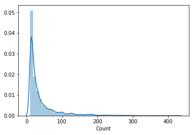

```python
sns.distplot(male["Count"])
```

```python
female.head()
```

|  | Gender | Count |
| --- | --- | --- |
| 0 | FEMALE | 13 |
| 1 | FEMALE | 21 |
| 2 | FEMALE | 49 |
| 3 | FEMALE | 38 |
| 4 | FEMALE | 36 |

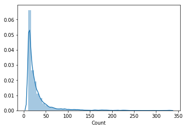

```python
sns.distplot(female["Count"])
```

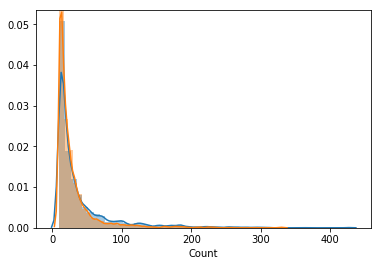

```python
sns.distplot(male["Count"])
sns.distplot(female["Count"])
```

We are able to compare the data between girls and boys to see the amount of times each name was being given. By looking at the count and adding those numbers up for each gender, we are able to get a sense of how many boys and girls were born between the years 2011-2014. When we put it onto a chart, we are able to see how the two populations of boys and girls overlap.

*Here we are able to see the sum of all males born in NYC from the years 2011-2014*

```python
sumMalesBorn = names.loc[gender=='MALE', 'Count'].sum()
```

```python
sumMalesBorn
```

```
428785
```

*Here we are able to see the sum of all females born in NYC from the years 2011-2014*

```python
sumFemalesBorn = names.loc[gender=='FEMALE', 'Count'].sum()
```

```python
sumFemalesBorn
```

```
331705
```

It is clear that 428,785 is larger than 331,705 - therefore the total birthrate of boys was larger than the total birthrate of girls between the years 2011-2014.

***Note that this means that the amount of boys born within those 4 years was larger than that of the girls. It does **NOT** mean that the amount of boys born each year was larger than that of the girls. Some years there might have been more girls than boys born, but overall it was the boys that were born more frequently***

# Boxplot

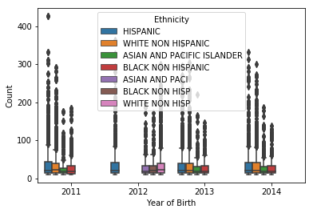

```python
sns.boxplot(x = "Year of Birth", y = "Count", hue = "Ethnicity", data=names)
```

**By using a boxplot, we are able to see the count of all the names of all the ethnicities of the mothers within NYC between the years 2011-2014.**

# Violin Plot

*Here is the same data as before, but placed on a violin plot*

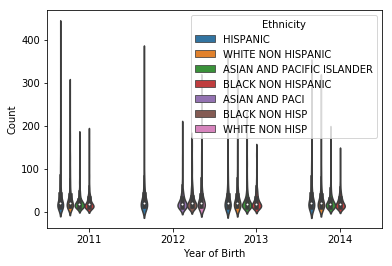

```python
sns.violinplot(x="Year of Birth", y="Count", hue="Ethnicity", data=names)
```

### Violin Plot with Gender

*Here we will take a look at all the counts of all the names of both Females and Males born within the years 2011-2014*

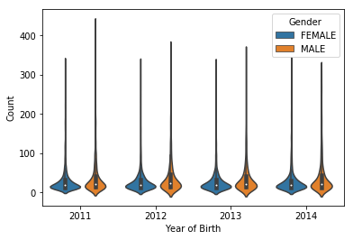

```python
sns.violinplot(x="Year of Birth", y="Count", hue="Gender", data=names)
```

*We can even take this violin plot and combine the genders together so that we can have a better comparison of the Female names to the Male names each year*

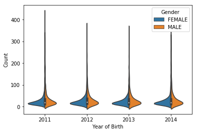

```python
sns.violinplot(x="Year of Birth", y="Count", hue="Gender", data=names, split=True)
```

# Bar Plot

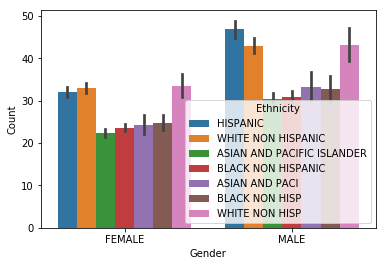

```python
sns.barplot(x="Gender", y="Count", hue="Ethnicity", data=names);
```

*Here we have a bar plot that compares data between the females and males born within the years 2011-2014*

# Top 10 Names

```python
top = names[rank <= 10]
```

```python
top
```

|  | Year of Birth | Gender | Ethnicity | Child's First Name | Count | Rank |
| --- | --- | --- | --- | --- | --- | --- |
| 6 | 2011 | FEMALE | HISPANIC | HAILEY | 126 | 8 |
| 22 | 2011 | FEMALE | HISPANIC | ISABELLA | 331 | 1 |
| 90 | 2011 | FEMALE | HISPANIC | LEAH | 123 | 9 |
| 109 | 2011 | FEMALE | HISPANIC | MADISON | 122 | 10 |
| 122 | 2011 | FEMALE | HISPANIC | MIA | 229 | 2 |
| 181 | 2011 | FEMALE | HISPANIC | SOFIA | 165 | 6 |
| 182 | 2011 | FEMALE | HISPANIC | SOPHIA | 223 | 3 |
| 248 | 2011 | FEMALE | WHITE NON HISPANIC | AVA | 162 | 8 |
| 279 | 2011 | FEMALE | WHITE NON HISPANIC | CHANA | 132 | 10 |
| 285 | 2011 | FEMALE | WHITE NON HISPANIC | CHAYA | 178 | 5 |
| 319 | 2011 | FEMALE | WHITE NON HISPANIC | EMMA | 213 | 2 |
| 322 | 2011 | FEMALE | WHITE NON HISPANIC | ESTHER | 224 | 1 |
| 365 | 2011 | FEMALE | WHITE NON HISPANIC | ISABELLA | 160 | 9 |
| 398 | 2011 | FEMALE | WHITE NON HISPANIC | LEAH | 183 | 3 |
| 456 | 2011 | FEMALE | WHITE NON HISPANIC | OLIVIA | 213 | 2 |
| 466 | 2011 | FEMALE | WHITE NON HISPANIC | RACHEL | 171 | 7 |
| 488 | 2011 | FEMALE | WHITE NON HISPANIC | SARAH | 177 | 6 |
| 508 | 2011 | FEMALE | WHITE NON HISPANIC | SOPHIA | 180 | 4 |
| 555 | 2011 | MALE | ASIAN AND PACIFIC ISLANDER | AIDEN | 96 | 7 |
| 585 | 2011 | MALE | ASIAN AND PACIFIC ISLANDER | DANIEL | 84 | 10 |
| 597 | 2011 | MALE | ASIAN AND PACIFIC ISLANDER | ERIC | 85 | 9 |
| 598 | 2011 | MALE | ASIAN AND PACIFIC ISLANDER | ETHAN | 177 | 1 |
| 620 | 2011 | MALE | ASIAN AND PACIFIC ISLANDER | JASON | 98 | 6 |
| 622 | 2011 | MALE | ASIAN AND PACIFIC ISLANDER | JAYDEN | 173 | 2 |
| 634 | 2011 | MALE | ASIAN AND PACIFIC ISLANDER | JUSTIN | 110 | 4 |
| 636 | 2011 | MALE | ASIAN AND PACIFIC ISLANDER | KEVIN | 92 | 8 |
| 645 | 2011 | MALE | ASIAN AND PACIFIC ISLANDER | LUCAS | 103 | 5 |
| 673 | 2011 | MALE | ASIAN AND PACIFIC ISLANDER | RYAN | 150 | 3 |
| 706 | 2011 | MALE | BLACK NON HISPANIC | AIDEN | 167 | 2 |
| 760 | 2011 | MALE | BLACK NON HISPANIC | ELIJAH | 156 | 3 |
| ... | ... | ... | ... | ... | ... | ... |
| 21191 | 2014 | MALE | HISPANIC | Noah | 282 | 3 |
| 21218 | 2014 | MALE | HISPANIC | Sebastian | 241 | 7 |
| 21255 | 2014 | MALE | WHITE NON HISPANIC | Alexander | 225 | 7 |
| 21284 | 2014 | MALE | WHITE NON HISPANIC | Benjamin | 233 | 6 |
| 21378 | 2014 | FEMALE | WHITE NON HISPANIC | Leah | 206 | 4 |
| 21436 | 2014 | FEMALE | WHITE NON HISPANIC | Miriam | 143 | 10 |
| 21452 | 2014 | FEMALE | WHITE NON HISPANIC | Olivia | 248 | 1 |
| 21466 | 2014 | FEMALE | WHITE NON HISPANIC | Rachel | 228 | 3 |
| 21492 | 2014 | FEMALE | WHITE NON HISPANIC | Sarah | 185 | 7 |
| 21511 | 2014 | FEMALE | WHITE NON HISPANIC | Sophia | 172 | 8 |
| 21559 | 2014 | MALE | ASIAN AND PACIFIC ISLANDER | Aiden | 135 | 5 |
| 21604 | 2014 | MALE | ASIAN AND PACIFIC ISLANDER | Daniel | 87 | 7 |
| 21619 | 2014 | MALE | ASIAN AND PACIFIC ISLANDER | Eric | 84 | 9 |
| 21620 | 2014 | MALE | ASIAN AND PACIFIC ISLANDER | Ethan | 179 | 2 |
| 21646 | 2014 | MALE | ASIAN AND PACIFIC ISLANDER | Jason | 78 | 10 |
| 21648 | 2014 | MALE | ASIAN AND PACIFIC ISLANDER | Jayden | 187 | 1 |
| 21676 | 2014 | MALE | ASIAN AND PACIFIC ISLANDER | Lucas | 139 | 4 |
| 21688 | 2014 | MALE | ASIAN AND PACIFIC ISLANDER | Muhammad | 129 | 6 |
| 21709 | 2014 | MALE | ASIAN AND PACIFIC ISLANDER | Ryan | 164 | 3 |
| 21731 | 2014 | MALE | ASIAN AND PACIFIC ISLANDER | William | 85 | 8 |
| 21747 | 2014 | MALE | BLACK NON HISPANIC | Aiden | 121 | 3 |
| 21754 | 2014 | MALE | BLACK NON HISPANIC | Amir | 101 | 10 |
| 21762 | 2014 | MALE | WHITE NON HISPANIC | Daniel | 223 | 8 |
| 21765 | 2014 | MALE | WHITE NON HISPANIC | David | 272 | 2 |
| 21836 | 2014 | MALE | WHITE NON HISPANIC | Jack | 199 | 10 |
| 21838 | 2014 | MALE | WHITE NON HISPANIC | Jacob | 256 | 5 |
| 21855 | 2014 | MALE | WHITE NON HISPANIC | Joseph | 300 | 1 |
| 21910 | 2014 | MALE | WHITE NON HISPANIC | Michael | 268 | 3 |
| 21921 | 2014 | MALE | WHITE NON HISPANIC | Moshe | 267 | 4 |
| 21970 | 2014 | MALE | WHITE NON HISPANIC | Samuel | 206 | 9 |

931 rows × 6 columns

*It seems like the the rankings are based off of the other variables. Ex: In 2011, if you are born a male to a Hispanic mother, and your name is ranked top 10, then you are only top ten to the group where the other top 10 are males born to Hispanic mothers in 2011. The ranking does not rank all the names from all the years.*

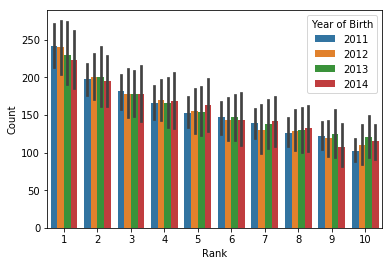

```python
sns.barplot(x= "Rank", y = "Count", hue = "Year of Birth", data=top)
```